# Quantitative Trading System Analysis

Random Forest-Based Holiday Return Prediction Model

Thomas Benacci

January 11, 2026

# 1 Environment Setup

## 1.1 Required Libraries

```r
library(tidyverse)
library(lubridate)
library(zoo)
library(pbapply)
library(data.table)
library(scales)
library(knitr)
library(kableExtra)

# Define a consistent color palette for visualizations
palette_main <- c(

  "RF1" = "#2E86AB",
  "1/N Stock Universe" = "#A23B72",
  "SPY Benchmark" = "#F18F01",
  "Top_5" = "#C73E1D",
  "Top_10" = "#2E86AB",
  "Top_20" = "#3B9A74",
  "Top_50" = "#7B68EE",
  "Top_100" = "#FF6B6B",
  "Top_250" = "#4ECDC4"
)

# Professional theme for ggplot
theme_trading <- function() {

  theme_minimal(base_size = 12) +
    theme(
      plot.title = element_text(face = "bold", size = 14, hjust = 0),
      plot.subtitle = element_text(color = "gray40", size = 11, hjust = 0),
      plot.caption = element_text(color = "gray50", size = 9, hjust = 1),
      panel.grid.minor = element_blank(),
      panel.grid.major = element_line(color = "gray90"),
      legend.position = "bottom",
      legend.title = element_text(face = "bold", size = 10),
      axis.title = element_text(face = "bold", size = 10),
      strip.text = element_text(face = "bold")
    )
}
```

# 2 Data Import and Preprocessing

## 2.1 Load Feature Data and Model Predictions

```r
# Load feature dataset containing stock characteristics
feature_data <- fread("feature_data_holiday_20251112.csv", data.table = FALSE) %>%
  distinct(datadate, tic, .keep_all = TRUE) %>%
  mutate(model = "RF1")

# Load Random Forest model predictions
results_data <- fread("rf_holiday_results_20251112_entropy.csv", data.table = FALSE) %>%
  select(datadate, tic, prediction)

# Merge datasets and standardize column names
data <- merge(results_data, feature_data, all.x = TRUE) %>%
  filter(datadate <= "2025-01-01") %>%
  rename(
    spy_return = spy_holiday_return,
    return = holiday_return
  )

# Clean up intermediate objects
rm(feature_data, results_data)

cat("Dataset dimensions:", nrow(data), "observations x", ncol(data), "variables\n")
```

```
## Dataset dimensions: 406500 observations x 46 variables
```

```r
cat("Date range:", as.character(min(data$datadate)), "to", as.character(max(data$datadate)), "\n")
```

```
## Date range: 2009-01-08 to 2024-12-26
```

```r
cat("Unique tickers:", length(unique(data$tic)), "\n")
```

```
## Unique tickers: 1013
```

## 2.2 Load Federal Funds Rate Data

```r
fedfunds <- fread("FEDFUNDS.csv", data.table = FALSE) %>%
  mutate(
    FEDFUNDS = FEDFUNDS / 100,
    rf_weekly = (1 + FEDFUNDS)^(1/52) - 1,
    rf_daily = (1 + FEDFUNDS)^(1/252) - 1
  )
```

# 3 Exploratory Data Analysis

## 3.1 Excess Return Distribution

Excess returns are calculated as the difference between individual stock returns and the SPY benchmark return for each period.

```r
excess_returns <- data$return - data$spy_return

# Summary statistics
excess_summary <- data.frame(
  Statistic = c("Mean", "Median", "Std Dev", "Min", "Max", "Skewness", "Kurtosis"),
  Value = c(
    round(mean(excess_returns, na.rm = TRUE), 4),
    round(median(excess_returns, na.rm = TRUE), 4),
    round(sd(excess_returns, na.rm = TRUE), 4),
    round(min(excess_returns, na.rm = TRUE), 4),
    round(max(excess_returns, na.rm = TRUE), 4),
    round(moments::skewness(excess_returns, na.rm = TRUE), 4),
    round(moments::kurtosis(excess_returns, na.rm = TRUE), 4)
  )
)

kable(excess_summary, caption = "Excess Returns Summary Statistics") %>%
  kable_styling(bootstrap_options = c("striped", "hover"), full_width = FALSE)
```

Excess Returns Summary Statistics

| Statistic | Value |
| --- | --- |
| Mean | -0.0005 |
| Median | -0.0008 |
| Std Dev | 0.0373 |
| Min | -0.8742 |
| Max | 2.2742 |
| Skewness | 1.0332 |
| Kurtosis | 63.3548 |

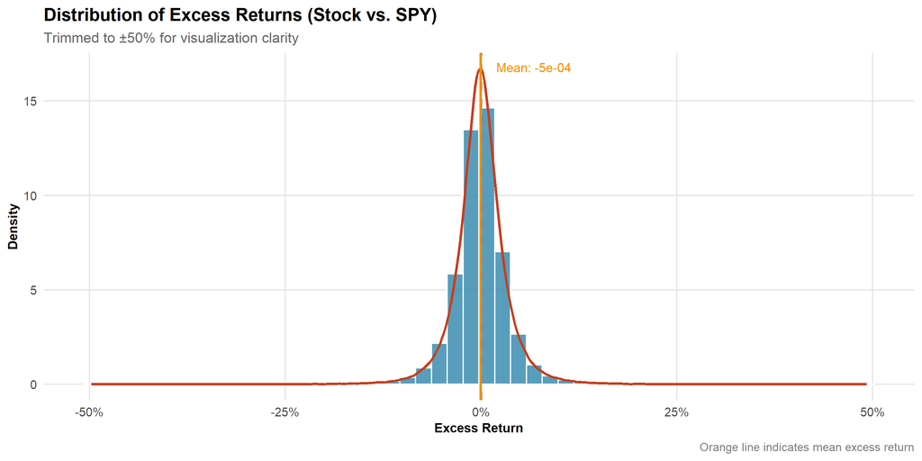

```r
# Trim extreme values for visualization
excess_returns_trimmed <- excess_returns[excess_returns > -0.5 & excess_returns < 0.5]

ggplot(data.frame(excess_return = excess_returns_trimmed), aes(x = excess_return)) +
  geom_histogram(aes(y = after_stat(density)), bins = 50, fill = "#2E86AB", color = "white", alpha = 0.8) +
  geom_density(color = "#C73E1D", linewidth = 1) +
  geom_vline(xintercept = 0, linetype = "dashed", color = "gray40", linewidth = 0.8) +
  geom_vline(xintercept = mean(excess_returns_trimmed), color = "#F18F01", linewidth = 1) +
  annotate("text", x = mean(excess_returns_trimmed) + 0.02, y = Inf,
           label = paste("Mean:", round(mean(excess_returns_trimmed), 4)),
           vjust = 2, hjust = 0, size = 3.5, color = "#F18F01") +
  labs(
    title = "Distribution of Excess Returns (Stock vs. SPY)",
    subtitle = "Trimmed to ±50% for visualization clarity",
    x = "Excess Return",
    y = "Density",
    caption = "Orange line indicates mean excess return"
  ) +
  theme_trading() +
  scale_x_continuous(labels = percent_format())
```

**Interpretation:** The distribution of excess returns is centered closely around zero, indicating no systematic edge inherent in the betting universe. This is consistent with weak-form market efficiency and reinforces the importance of a robust prediction model.

## 3.2 Target Variable Analysis

The target variable is a binary indicator: 1 if the stock return exceeds the SPY return, 0 otherwise.

```r
target_mean <- mean(data$target)

cat("Overall target mean (2004-2024):", round(target_mean, 3), "\n")
```

[output not shown]

```r
cat("Interpretation: A random selection has a", round(target_mean * 100, 1),
    "% probability of beating the benchmark.\n")
```

```
## Interpretation: A random selection has a 48.6 % probability of beating the benchmark.
```

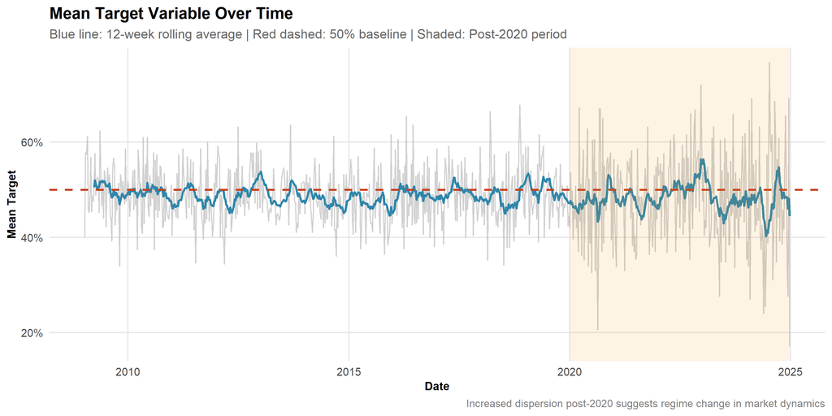

```r
# Calculate mean target by date
df_target <- data %>%
  group_by(datadate) %>%
  summarize(mean_target = mean(target), .groups = "drop") %>%
  mutate(
    datadate = as.Date(datadate),
    rolling_mean = zoo::rollmean(mean_target, k = 12, fill = NA, align = "right")
  )

ggplot(df_target, aes(x = datadate)) +
  geom_line(aes(y = mean_target), color = "gray70", alpha = 0.6) +
  geom_line(aes(y = rolling_mean), color = "#2E86AB", linewidth = 1) +
  geom_hline(yintercept = 0.5, linetype = "dashed", color = "#C73E1D", linewidth = 0.8) +
  annotate("rect", xmin = as.Date("2020-01-01"), xmax = max(df_target$datadate),
           ymin = -Inf, ymax = Inf, alpha = 0.1, fill = "#F18F01") +
  labs(
    title = "Mean Target Variable Over Time",
    subtitle = "Blue line: 12-week rolling average | Red dashed: 50% baseline | Shaded: Post-2020 period",
    x = "Date",
    y = "Mean Target",
    caption = "Increased dispersion post-2020 suggests regime change in market dynamics"
  ) +
  theme_trading() +
  scale_y_continuous(labels = percent_format())
```

**Interpretation:** Post-2020, the weekly mean target exhibits significantly higher dispersion compared to earlier periods. This presents two practical challenges: (1) reduced predictability using historical training data due to distribution shift, and (2) indication that the benchmark (SPY) has become increasingly concentrated in fewer securities, reducing its representativeness of the broader market.

# 4 Feature Analysis

## 4.1 Feature Correlation Structure

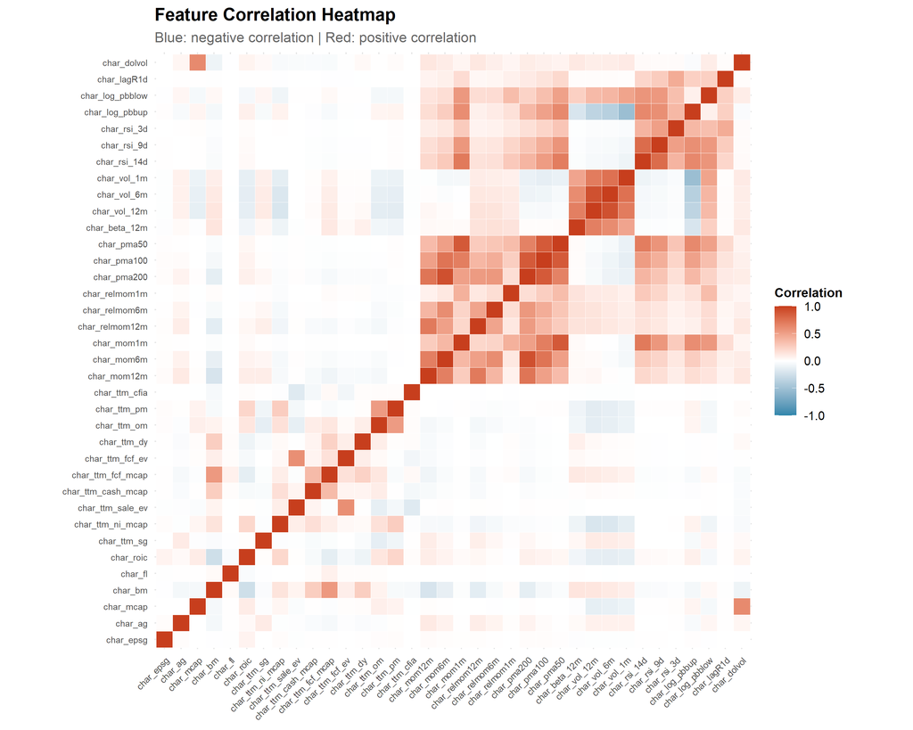

```r
feature_cor_mat <- data %>%
  select(starts_with("char_")) %>%
  cor(use = "pairwise.complete.obs") %>%
  round(3)

# Convert to long format for ggplot
cor_long <- as.data.frame(as.table(feature_cor_mat)) %>%
  rename(Feature1 = Var1, Feature2 = Var2, Correlation = Freq)

ggplot(cor_long, aes(x = Feature1, y = Feature2, fill = Correlation)) +
  geom_tile(color = "white", linewidth = 0.1) +
  scale_fill_gradient2(
    low = "#2E86AB", mid = "white", high = "#C73E1D",
    midpoint = 0, limits = c(-1, 1),
    name = "Correlation"
  ) +
  labs(
    title = "Feature Correlation Heatmap",
    subtitle = "Blue: negative correlation | Red: positive correlation",
    x = NULL, y = NULL
  ) +
  theme_trading() +
  theme(
    axis.text.x = element_text(angle = 45, hjust = 1, size = 7),
    axis.text.y = element_text(size = 7),
    legend.position = "right"
  ) +
  coord_fixed()
```

**Interpretation:** Fundamental characteristics remain largely uncorrelated with each other and with technical indicators. However, technical characteristics exhibit high inter-correlation, which may introduce multicollinearity concerns in the prediction model.

## 4.2 Feature-Target Correlations

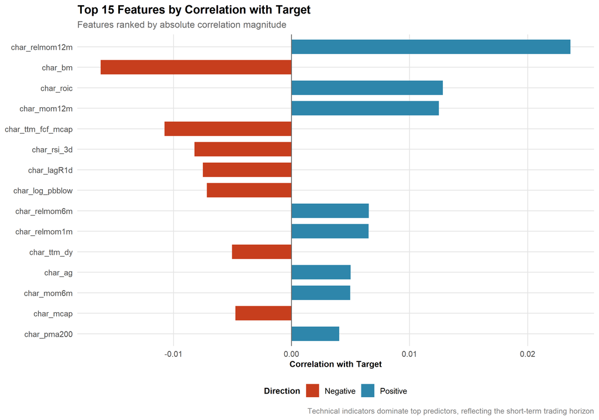

```r
target_feature_cors <- sapply(data[grep("^char_", names(data))], function(x) cor(data$target, x, use = "complete.obs"))

# Create sorted dataframe
cor_df <- data.frame(
  Feature = names(target_feature_cors),
  Correlation = as.numeric(target_feature_cors)
) %>%
  arrange(desc(abs(Correlation))) %>%
  mutate(
    Feature = factor(Feature, levels = Feature),
    Direction = ifelse(Correlation > 0, "Positive", "Negative")
  )

# Top 15 features by absolute correlation
top_features <- head(cor_df, 15)

ggplot(top_features, aes(x = reorder(Feature, abs(Correlation)), y = Correlation, fill = Direction)) +
  geom_col(width = 0.7) +
  coord_flip() +
  scale_fill_manual(values = c("Positive" = "#2E86AB", "Negative" = "#C73E1D")) +
  labs(
    title = "Top 15 Features by Correlation with Target",
    subtitle = "Features ranked by absolute correlation magnitude",
    x = NULL,
    y = "Correlation with Target",
    caption = "Technical indicators dominate top predictors, reflecting the short-term trading horizon"
  ) +
  theme_trading() +
  geom_hline(yintercept = 0, linetype = "solid", color = "gray40")
```

# 5 Portfolio Construction and Analysis

## 5.1 Helper Functions and Parameters

```r
# Core parameters
sizes <- c(5, 10, 20, 50, 100, 250)
prob_weighted <- TRUE
periods_per_year <- 252 / 5  # Weekly trading periods

# Date mapping for year labels
unique_dates <- unique(data$datadate)
year_labels <- seq(2009, 2025, length.out = length(unique_dates))
date_to_year <- setNames(year_labels, unique_dates)
```

## 5.2 Feature-Based Portfolio Formation

```r
feature_list <- names(target_feature_cors)

make_feature_portfolios <- function(feature_name) {
  cors <- target_feature_cors[feature_name]

  make_portfolio <- function(n_long) {
    longs <- data %>%
      group_by(datadate) %>%
      {
        if (cors > 0) {
          arrange(., desc(.data[[feature_name]]), .by_group = TRUE) %>%
            slice_head(n = n_long)
        } else {
          arrange(., .data[[feature_name]], .by_group = TRUE) %>%
            slice_head(n = n_long)
        }
      } %>%
      ungroup()

    port <- longs %>%
      group_by(datadate) %>%
      summarise(
        return = if (prob_weighted)
          weighted.mean(return, .data[[feature_name]], na.rm = TRUE)
        else
          mean(return, na.rm = TRUE),
        .groups = "drop"
      ) %>%
      mutate(
        model = paste0(feature_name, "_Top_", n_long),
        datadate = as.Date(datadate),
        year = date_to_year[as.character(datadate)]
      ) %>%
      arrange(datadate) %>%
      group_by(model) %>%
      mutate(cumulative_return = cumprod(1 + return)) %>%
      ungroup()

    return(port)
  }

  map_dfr(sizes, make_portfolio)
}

all_feature_portfolios <- map_dfr(feature_list, make_feature_portfolios)

# Add benchmarks
equal_weighted_returns <- data %>%
  group_by(datadate) %>%
  summarise(return = mean(return), .groups = "drop") %>%
  mutate(
    model = "1/N Stock Universe",
    cumulative_return = cumprod(1 + return),
    year = date_to_year[as.character(datadate)],
    datadate = as.Date(datadate)
  )

spy_portfolio <- data %>%
  group_by(datadate) %>%
  summarise(return = mean(spy_return), .groups = "drop") %>%
  mutate(
    model = "SPY Benchmark",
    cumulative_return = cumprod(1 + return),
    year = date_to_year[as.character(datadate)],
    datadate = as.Date(datadate)
  )

all_feature_portfolios <- bind_rows(all_feature_portfolios, equal_weighted_returns, spy_portfolio)
```

## 5.3 Feature Portfolio Metrics

```r
spy_returns <- all_feature_portfolios %>%
  filter(model == "SPY Benchmark") %>%
  select(datadate, spy_return = return)

portfolios_with_spy <- all_feature_portfolios %>%
  left_join(spy_returns, by = "datadate")

all_feature_metrics <- portfolios_with_spy %>%
  group_by(model) %>%
  summarise(
    ann_return = mean(return, na.rm = TRUE) * periods_per_year,
    ann_vol = sd(return, na.rm = TRUE) * sqrt(periods_per_year),
    return_vol = ann_return / ann_vol,
    max_drawdown = {
      cum_ret <- cumprod(1 + return)
      drawdown <- (cum_ret - cummax(cum_ret)) / cummax(cum_ret)
      min(drawdown, na.rm = TRUE)
    },
    information_ratio = if (unique(model) == "SPY Benchmark") {
      NA
    } else {
      active <- return - spy_return
      act_ret <- mean(active, na.rm = TRUE) * periods_per_year
      te <- sd(active, na.rm = TRUE) * sqrt(periods_per_year)
      act_ret / te
    },
    .groups = "drop"
  ) %>%
  mutate(across(where(is.numeric), ~ round(., 3)))

# Top performers by Information Ratio
top_feature_performers <- all_feature_metrics %>%
  arrange(desc(information_ratio)) %>%
  head(20)

kable(top_feature_performers,
      caption = "Top 20 Feature Portfolios by Information Ratio",
      col.names = c("Model", "Ann. Return", "Ann. Volatility", "Return/Vol", "Max Drawdown", "Info Ratio")) %>%
  kable_styling(bootstrap_options = c("striped", "hover"), full_width = FALSE)
```

Top 20 Feature Portfolios by Information Ratio

| Model | Ann. Return | Ann. Volatility | Return/Vol | Max Drawdown | Info Ratio |
| --- | --- | --- | --- | --- | --- |
| char_bm_Top_5 | 0.212 | 0.216 | 0.981 | -0.269 | 0.601 |
| char_bm_Top_20 | 0.175 | 0.175 | 1.001 | -0.299 | 0.575 |
| char_relmom12m_Top_5 | 0.361 | 0.503 | 0.718 | -0.491 | 0.552 |
| char_relmom12m_Top_10 | 0.322 | 0.438 | 0.735 | -0.450 | 0.551 |
| char_rsi_3d_Top_5 | 0.206 | 0.218 | 0.944 | -0.334 | 0.528 |
| char_bm_Top_10 | 0.183 | 0.191 | 0.956 | -0.285 | 0.511 |
| char_bm_Top_50 | 0.161 | 0.172 | 0.932 | -0.229 | 0.499 |
| char_relmom12m_Top_20 | 0.270 | 0.377 | 0.716 | -0.403 | 0.495 |
| char_relmom12m_Top_50 | 0.229 | 0.310 | 0.739 | -0.346 | 0.469 |
| char_relmom12m_Top_100 | 0.203 | 0.274 | 0.742 | -0.307 | 0.427 |
| char_rsi_3d_Top_10 | 0.176 | 0.207 | 0.851 | -0.325 | 0.381 |
| char_bm_Top_100 | 0.151 | 0.176 | 0.862 | -0.259 | 0.372 |
| char_ttm_sale_ev_Top_5 | 0.181 | 0.213 | 0.850 | -0.339 | 0.369 |
| char_rsi_3d_Top_20 | 0.169 | 0.202 | 0.837 | -0.358 | 0.367 |
| char_ttm_sale_ev_Top_10 | 0.174 | 0.202 | 0.859 | -0.341 | 0.366 |
| char_relmom12m_Top_250 | 0.183 | 0.252 | 0.727 | -0.292 | 0.359 |
| char_relmom6m_Top_5 | 0.286 | 0.547 | 0.524 | -0.527 | 0.345 |
| char_relmom6m_Top_10 | 0.250 | 0.462 | 0.542 | -0.496 | 0.333 |
| char_relmom1m_Top_5 | 0.268 | 0.515 | 0.520 | -0.530 | 0.321 |
| char_ttm_sale_ev_Top_250 | 0.163 | 0.201 | 0.814 | -0.333 | 0.314 |

# 6 RF1 Model Portfolio Analysis

## 6.1 Portfolio Formation (N = 10)

```r
n_long <- 10
n_short <- 0
weighing_method <- ifelse(prob_weighted, "Probability-Weighted", "Equal-Weighted")

# Long position selection based on prediction probability
selected <- data %>%
  arrange(datadate, desc(prediction)) %>%
  group_by(datadate, model) %>%
  slice_head(n = n_long) %>%
  ungroup()

# Calculate portfolio returns
portfolios <- selected %>%
  group_by(datadate, model) %>%
  summarise(
    return = if (prob_weighted) weighted.mean(return, prediction) else mean(return),
    .groups = "drop"
  ) %>%
  group_by(model) %>%
  arrange(datadate) %>%
  mutate(
    cumulative_return = cumprod(1 + return),
    datadate = as.Date(datadate)
  ) %>%
  ungroup() %>%
  mutate(year = date_to_year[as.character(datadate)])

# Add benchmarks
equal_weighted_returns <- data %>%
  group_by(datadate) %>%
  summarise(return = mean(return), .groups = "drop") %>%
  mutate(
    model = "1/N Stock Universe",
    cumulative_return = cumprod(1 + return),
    year = date_to_year[as.character(datadate)],
    datadate = as.Date(datadate)
  )

spy_portfolio <- data %>%
  group_by(datadate) %>%
  summarise(return = mean(spy_return), .groups = "drop") %>%
  mutate(
    model = "SPY Benchmark",
    cumulative_return = cumprod(1 + return),
    year = date_to_year[as.character(datadate)],
    datadate = as.Date(datadate)
  )

portfolios <- bind_rows(portfolios, equal_weighted_returns, spy_portfolio)
```

## 6.2 Cumulative Performance Visualization

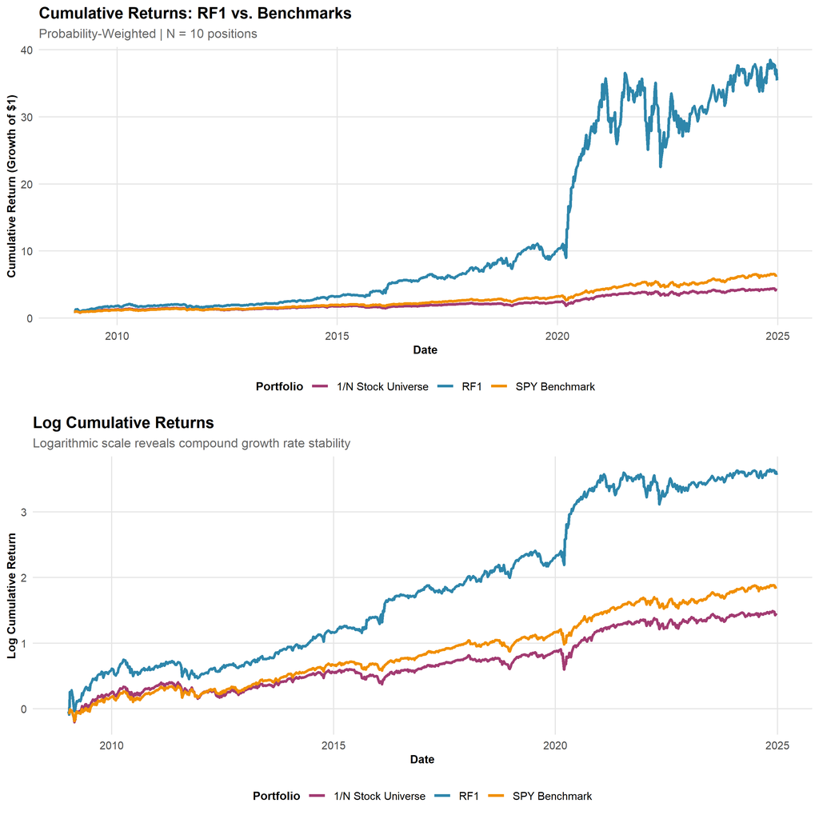

```r
# Linear scale plot
p1 <- ggplot(portfolios, aes(x = datadate, y = cumulative_return, color = model)) +
  geom_line(linewidth = 1.2) +
  scale_color_manual(values = palette_main) +
  scale_y_continuous(labels = scales::comma) +
  labs(
    title = "Cumulative Returns: RF1 vs. Benchmarks",
    subtitle = paste0(weighing_method, " | N = ", n_long, " positions"),
    x = "Date",
    y = "Cumulative Return (Growth of $1)",
    color = "Portfolio"
  ) +
  theme_trading()

# Log scale plot
p2 <- ggplot(portfolios, aes(x = datadate, y = log(cumulative_return), color = model)) +
  geom_line(linewidth = 1.2) +
  scale_color_manual(values = palette_main) +
  labs(
    title = "Log Cumulative Returns",
    subtitle = "Logarithmic scale reveals compound growth rate stability",
    x = "Date",
    y = "Log Cumulative Return",
    color = "Portfolio"
  ) +
  theme_trading()

# Combine plots
gridExtra::grid.arrange(p1, p2, ncol = 1)
```

**Note:** These plots serve primarily for visual intuition. Using them as definitive arguments for or against strategies is inadvisable due to look-ahead bias concerns. The log cumulative plot may be useful for identifying strategy performance decay over time.

## 6.3 Performance Metrics Summary

```r
spy_returns <- portfolios %>%
  filter(model == "SPY Benchmark") %>%
  select(datadate, spy_return = return)

portfolios_with_spy <- portfolios %>%
  left_join(spy_returns, by = "datadate")

metrics_by_model <- portfolios_with_spy %>%
  group_by(model) %>%
  summarise(
    `Annualized Return` = mean(return, na.rm = TRUE) * periods_per_year,
    `Annualized Volatility` = sd(return, na.rm = TRUE) * sqrt(periods_per_year),
    `Return/Volatility` = `Annualized Return` / `Annualized Volatility`,
    `Max Drawdown` = {
      cum_ret <- cumprod(1 + return)
      drawdown <- (cum_ret - cummax(cum_ret)) / cummax(cum_ret)
      min(drawdown, na.rm = TRUE)
    },
    `Information Ratio` = {
      if (unique(model) == "SPY Benchmark") {
        NA_real_
      } else {
        active_ret <- return - spy_return
        mean_active <- mean(active_ret, na.rm = TRUE) * periods_per_year
        tracking_error <- sd(active_ret, na.rm = TRUE) * sqrt(periods_per_year)
        ifelse(tracking_error != 0, mean_active / tracking_error, NA_real_)
      }
    },
    .groups = "drop"
  ) %>%
  mutate(across(where(is.numeric), ~ round(., 3)))

kable(metrics_by_model, caption = "Portfolio Performance Metrics (2009-2024)") %>%
  kable_styling(bootstrap_options = c("striped", "hover"), full_width = FALSE) %>%
  row_spec(which(metrics_by_model$model == "RF1"), bold = TRUE, background = "#E8F4F8")
```

Portfolio Performance Metrics (2009-2024)

| model | Annualized Return | Annualized Volatility | Return/Volatility | Max Drawdown | Information Ratio |
| --- | --- | --- | --- | --- | --- |
| 1/N Stock Universe | 0.103 | 0.170 | 0.606 | -0.266 | -0.496 |
| RF1 | 0.266 | 0.306 | 0.867 | -0.384 | 0.621 |
| SPY Benchmark | 0.127 | 0.151 | 0.836 | -0.203 | NA |

**Interpretation:** Between 2009 and 2024, the RF1 trading system (N=10) delivers more than double the annualized return of both the 1/N Universe and SPY benchmark. However, this comes with approximately twice the volatility, resulting in comparable Sharpe-like ratios. The maximum drawdown of nearly 40% (occurring within 12 months) represents significant tail risk that must be considered in capital allocation decisions. An Information Ratio between 0.5 and 1.0 is generally considered good to very good, with values exceeding 1.0 being exceptional.

# 7 Portfolio Size Sensitivity Analysis

## 7.1 Performance Across Different Portfolio Sizes

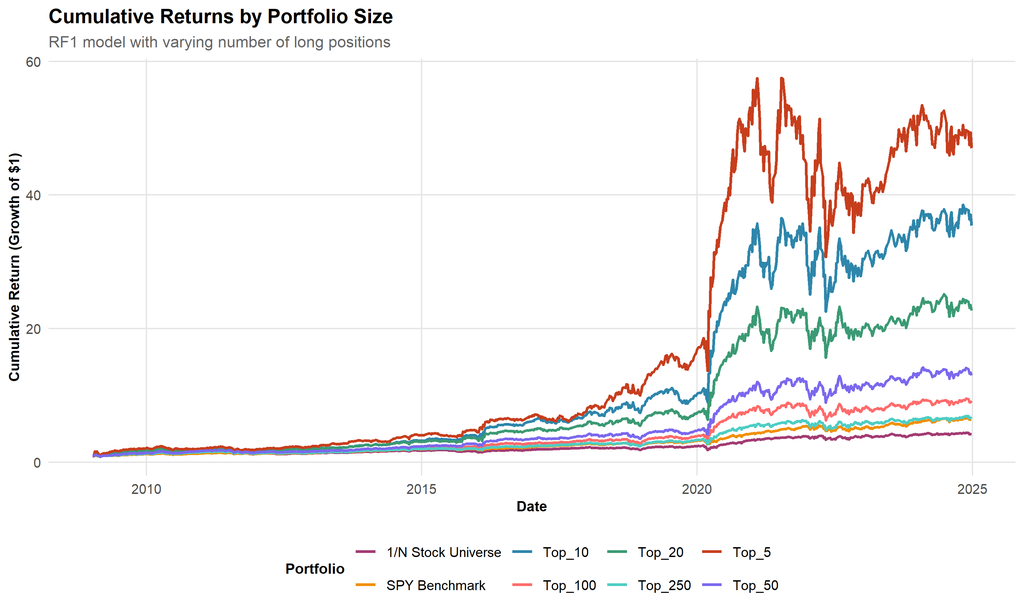

```r
make_portfolio_size <- function(n_long) {
  longs <- data %>%
    arrange(datadate, desc(prediction)) %>%
    group_by(datadate, model) %>%
    slice_head(n = n_long) %>%
    ungroup()

  port <- longs %>%
    group_by(datadate, model) %>%
    summarise(
      return = if (prob_weighted) weighted.mean(return, prediction) else mean(return),
      .groups = "drop"
    ) %>%
    mutate(
      model = paste0("Top_", n_long),
      datadate = as.Date(datadate),
      year = date_to_year[as.character(datadate)]
    ) %>%
    arrange(datadate) %>%
    group_by(model) %>%
    mutate(cumulative_return = cumprod(1 + return)) %>%
    ungroup()

  return(port)
}

portfolios_all <- map_dfr(sizes, make_portfolio_size)

# Add benchmarks
equal_weighted_all <- data %>%
  group_by(datadate) %>%
  summarise(return = mean(return), .groups = "drop") %>%
  mutate(
    model = "1/N Stock Universe",
    cumulative_return = cumprod(1 + return),
    year = date_to_year[as.character(datadate)],
    datadate = as.Date(datadate)
  )

spy_all <- data %>%
  group_by(datadate) %>%
  summarise(return = mean(spy_return), .groups = "drop") %>%
  mutate(
    model = "SPY Benchmark",
    cumulative_return = cumprod(1 + return),
    year = date_to_year[as.character(datadate)],
    datadate = as.Date(datadate)
  )

portfolios_all <- bind_rows(portfolios_all, equal_weighted_all, spy_all)

# Visualize cumulative returns by portfolio size
ggplot(portfolios_all, aes(x = datadate, y = cumulative_return, color = model)) +
  geom_line(linewidth = 1) +
  scale_color_manual(values = palette_main) +
  scale_y_continuous(labels = scales::comma) +
  labs(
    title = "Cumulative Returns by Portfolio Size",
    subtitle = "RF1 model with varying number of long positions",
    x = "Date",
    y = "Cumulative Return (Growth of $1)",
    color = "Portfolio"
  ) +
  theme_trading()
```

```r
spy_returns_all <- portfolios_all %>%
  filter(model == "SPY Benchmark") %>%
  select(datadate, spy_return = return)

portfolios_all_spy <- portfolios_all %>%
  left_join(spy_returns_all, by = "datadate")

metrics_all <- portfolios_all_spy %>%
  group_by(model) %>%
  summarise(
    `Ann. Return` = mean(return, na.rm = TRUE) * periods_per_year,
    `Ann. Vol` = sd(return, na.rm = TRUE) * sqrt(periods_per_year),
    `Return/Vol` = `Ann. Return` / `Ann. Vol`,
    `Max DD` = {
      cum_ret <- cumprod(1 + return)
      drawdown <- (cum_ret - cummax(cum_ret)) / cummax(cum_ret)
      min(drawdown, na.rm = TRUE)
    },
    `Info Ratio` = if (unique(model) == "SPY Benchmark") {
      NA_real_
    } else {
      active <- return - spy_return
      act_ret <- mean(active, na.rm = TRUE) * periods_per_year
      te <- sd(active, na.rm = TRUE) * sqrt(periods_per_year)
      act_ret / te
    },
    .groups = "drop"
  ) %>%
  mutate(across(where(is.numeric), ~ round(., 3))) %>%
  mutate(
    n_long = ifelse(grepl("^Top_", model), as.numeric(sub("Top_", "", model)), Inf)
  ) %>%
  arrange(n_long) %>%
  select(-n_long)

kable(metrics_all, caption = "Performance Metrics by Portfolio Size") %>%
  kable_styling(bootstrap_options = c("striped", "hover"), full_width = FALSE)
```

Performance Metrics by Portfolio Size

| model | Ann. Return | Ann. Vol | Return/Vol | Max DD | Info Ratio |
| --- | --- | --- | --- | --- | --- |
| Top_5 | 0.299 | 0.371 | 0.807 | -0.466 | 0.570 |
| Top_10 | 0.266 | 0.306 | 0.867 | -0.384 | 0.621 |
| Top_20 | 0.230 | 0.275 | 0.836 | -0.327 | 0.557 |
| Top_50 | 0.188 | 0.243 | 0.773 | -0.291 | 0.411 |
| Top_100 | 0.159 | 0.219 | 0.724 | -0.294 | 0.272 |
| Top_250 | 0.134 | 0.187 | 0.714 | -0.229 | 0.099 |
| 1/N Stock Universe | 0.103 | 0.170 | 0.606 | -0.266 | -0.496 |
| SPY Benchmark | 0.127 | 0.151 | 0.836 | -0.203 | NA |

**Interpretation:** All RF1 portfolio configurations exhibit positive Information Ratios relative to SPY, indicating consistent alpha generation across different position sizes. As expected, concentrated portfolios (smaller N) exhibit higher volatility but also higher potential returns, while larger portfolios converge toward benchmark-like characteristics.

# 8 Return Distribution Analysis

## 8.1 RF1 vs. SPY Return Histograms

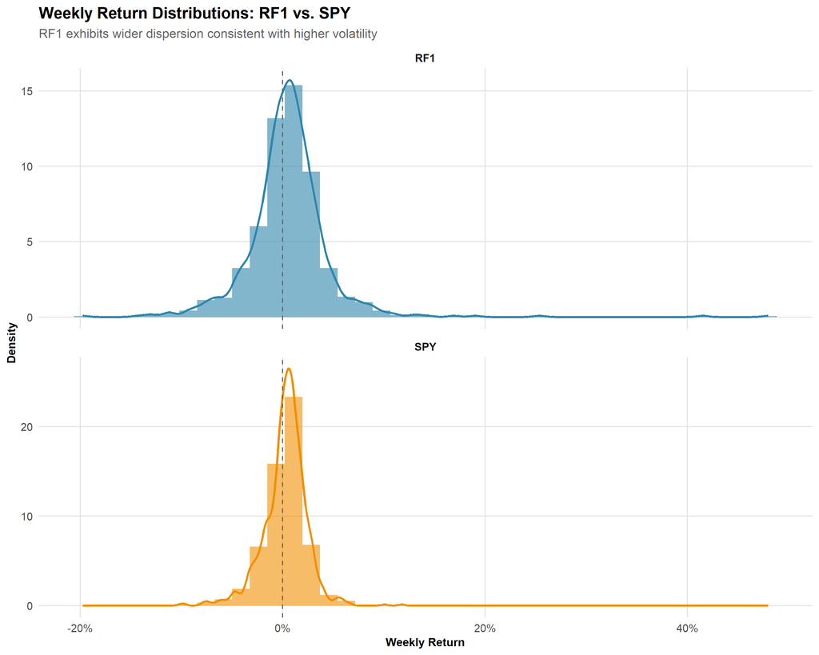

```r
RF1_returns <- portfolios %>%
  filter(model == "RF1") %>%
  select(datadate, return) %>%
  mutate(Portfolio = "RF1")

SPY_returns <- portfolios %>%
  filter(model == "SPY Benchmark") %>%
  select(datadate, return) %>%
  mutate(Portfolio = "SPY")

combined_returns <- bind_rows(RF1_returns, SPY_returns)

ggplot(combined_returns, aes(x = return, fill = Portfolio)) +
  geom_histogram(aes(y = after_stat(density)), bins = 40, alpha = 0.6, position = "identity") +
  geom_density(aes(color = Portfolio), linewidth = 1, fill = NA) +
  facet_wrap(~Portfolio, ncol = 1, scales = "free_y") +
  scale_fill_manual(values = c("RF1" = "#2E86AB", "SPY" = "#F18F01")) +
  scale_color_manual(values = c("RF1" = "#2E86AB", "SPY" = "#F18F01")) +
  geom_vline(xintercept = 0, linetype = "dashed", color = "gray40") +
  labs(
    title = "Weekly Return Distributions: RF1 vs. SPY",
    subtitle = "RF1 exhibits wider dispersion consistent with higher volatility",
    x = "Weekly Return",
    y = "Density"
  ) +
  theme_trading() +
  scale_x_continuous(labels = percent_format()) +
  theme(legend.position = "none")
```

# 9 Appendix: Data Export

```r
# Export returns for external simulation
RF1_returns_export <- portfolios %>%
  filter(model == "RF1") %>%
  select(datadate, return) %>%
  mutate(datadate = lag(datadate)) %>%
  drop_na()

SPY_returns_export <- portfolios %>%
  filter(model == "SPY Benchmark") %>%
  select(datadate, return) %>%
  mutate(datadate = lag(datadate)) %>%
  drop_na()

# Uncomment to save
# write.csv(RF1_returns_export, "RF1_returns.csv", row.names = FALSE)
# write.csv(SPY_returns_export, "SPY_returns.csv", row.names = FALSE)
```

**Report Generated:** January 11, 2026 at 12:14